# Project 1: Investigation of Class Size and First Grade Math Scores from Project STAR

1/17/2020

# Introduction

Project STAR (Student/Teacher Achievement Ratio) was a longitudinal, randomized study to investigate how class-size affected student math and reading performance in the 1980s. The study included 79 schools and over 7,000 students in Tennessee. There were three treatment groups: small class (13-17 students), regular class (22-25 students), and regular class with aide. Teachers and students were randomized to treatment groups to limit bias and confounding of the treatment effect. Students were followed for grades kindergarten through 3rd grade.

### Data Description

The collected data include records of 11,598 students. The variables associated with each student include demographics, school information, teacher information, treatment group (class type), and test scores for each grade. For the following analysis, we will consider variables associated with the first grade (with some brief consideration of kindergarten data). The data was retrieved from the “AER” R package.

# Exploratory Data Analysis

### Missingness

**Figure 1: Missing Data**

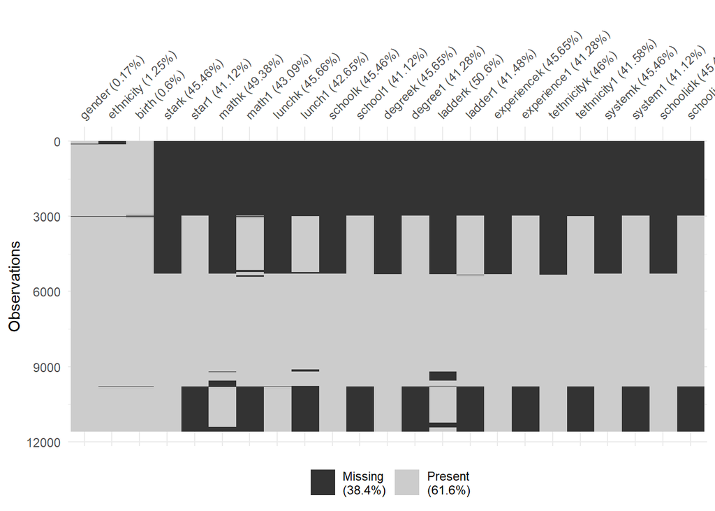

Are the students who are missing data from kindergarten different from the population of students who are not missing data from kindergarten? In other words, is the subset of students missing kindergarten data a random subset of the population of students who have first grade data available? Below are the boxplots of first grade math scores for students with and without kindergarten data. It is clear that those without kindergarten data tend to have lower scores. Note that kindergarten was not mandatory in Tennessee at this time.

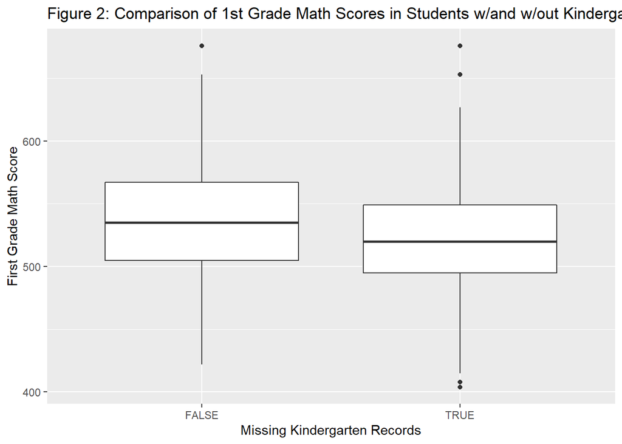

### Comparison of Treatment Groups by Covariates

Teachers and students were randomized in this study to avoid confounding or bias in the treatment groups. Ideally, the treatment groups have the same distribution of covariates so that the groups can be compared. In reality, because of randomization, there may be differences in the groups. Below is a table comparing the distributions of a selection of variables of interest across the three treatment groups for first grade. Of the selected variables, the treatment groups seem similar (as would be expected from randomization) except for a few interesting deviations. For one, the small class treatment group has a much lower proportion of students who are missing kindergarten data. This may be problematic for our analysis.

In addition, it first appears that 22 teachers with a PhD are only found in the regular with aide class type, and the 38 teachers with specialist degrees are only found in the small and regular with aide classes. However, note that these are actually counts of *students*, not teachers, such that the 22 students with a teacher who has a PhD are all in the same class. Thus, this does not indicate some failure of the randomization.

**Table 1: Distribution of Students by Class Size and Covariates**

|  | regular (n=2584) | small (n=1925) | regular+aide (n=2320) |
| --- | --- | --- | --- |
| Gender |  |  |  |
| male | 1326 (51.3%) | 990 (51.4%) | 1225 (52.8%) |
| female | 1254 (48.5%) | 934 (48.5%) | 1087 (46.9%) |
| Missing | 4 (0.2%) | 1 (0.1%) | 8 (0.3%) |
| Ethnicity |  |  |  |
| White | 1597 (61.8%) | 1306 (67.8%) | 1625 (70.0%) |
| Black | 957 (37.0%) | 599 (31.1%) | 665 (28.7%) |
| Other | 19 (0.7%) | 16 (0.8%) | 16 (0.7%) |
| Missing | 11 (0.4%) | 4 (0.2%) | 14 (0.6%) |
| Kindergarten Math Score |  |  |  |
| Mean (SD) | 489 (43.4) | 496 (48.1) | 489 (46.0) |
| Median [Min, Max] | 484 [365, 626] | 489 [354, 626] | 484 [354, 626] |
| Missing | 1120 (43.3%) | 483 (25.1%) | 978 (42.2%) |
| Qualifies for Free Lunch (1st Grade) |  |  |  |
| Yes | 1341 (51.9%) | 921 (47.8%) | 1168 (50.3%) |
| No | 1191 (46.1%) | 967 (50.2%) | 1063 (45.8%) |
| Missing | 52 (2.0%) | 37 (1.9%) | 89 (3.8%) |
| Missing Kindergarten |  |  |  |
| Yes | 1251 (48.4%) | 603 (31.3%) | 1107 (47.7%) |
| No | 1333 (51.6%) | 1322 (68.7%) | 1213 (52.3%) |
| Teacher Degree |  |  |  |
| Bachelor | 1793 (69.4%) | 1224 (63.6%) | 1439 (62.0%) |
| Master | 791 (30.6%) | 665 (34.5%) | 838 (36.1%) |
| Specialist | 0 (0%) | 17 (0.9%) | 21 (0.9%) |
| PhD | 0 (0%) | 0 (0%) | 22 (0.9%) |
| Missing | 0 (0%) | 19 (1.0%) | 0 (0%) |

### Exploratory Data Analysis with First-Grade Math Scores as Outcome of Interest

Now, we turn our focus to the outcome of interest - first grade math scores. Below is the histogram and QQ-plot of first grade math scores. We see that the distribution is fairly normal, yet someone right-skewed. The minimum score is 404, the median is 529, the mean is 530.5, and the maximum is 676.

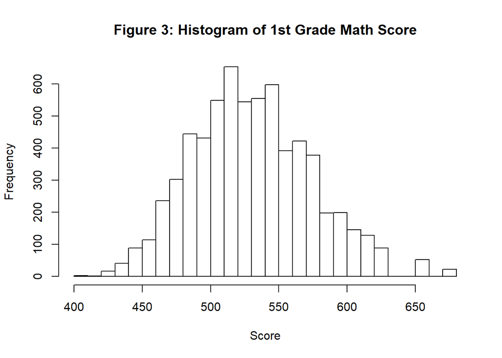

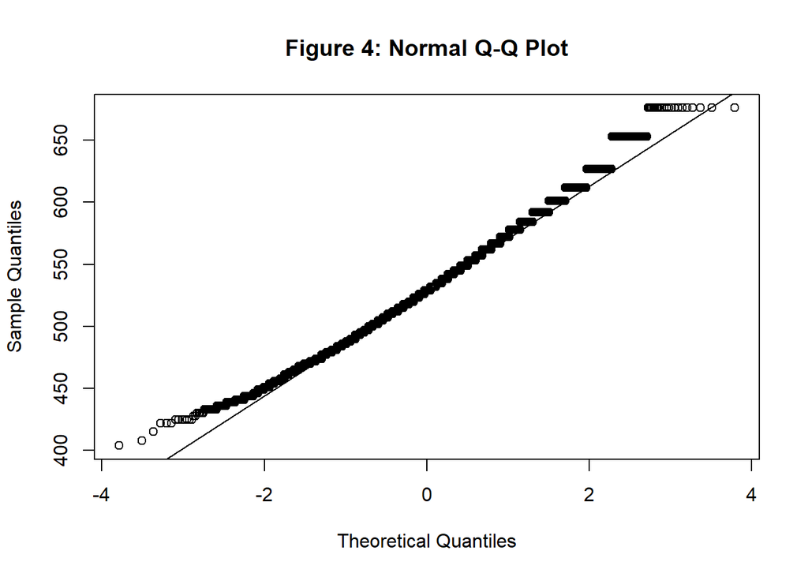

Many of the measured covariates are associated with first-grade math scores. Perhaps unsurprisingly, kindergarten math scores are positively correlated with first-grade math scores, as shown in the jittered scatterplot with a fitted LOESS curve shown below. One can see the regression to the mean in this plot - the extreme kindergarten scorers tend to regress closer to the mean in first grade, and vice-versa. Both the Spearman and Pearson correlation coefficients between the two variables are 0.60.

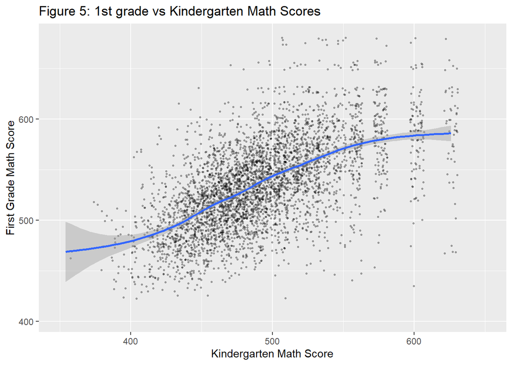

Students who qualified for free lunch had tended to have lower scores than than those who did not qualify, This is unsurprising, since qualifying for free lunch is a proxy for coming from a low-income household.

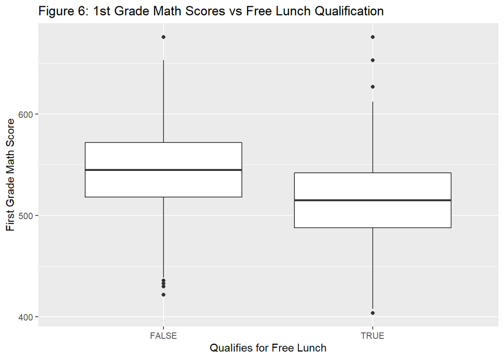

In addition, black students tended to score lower than white students.

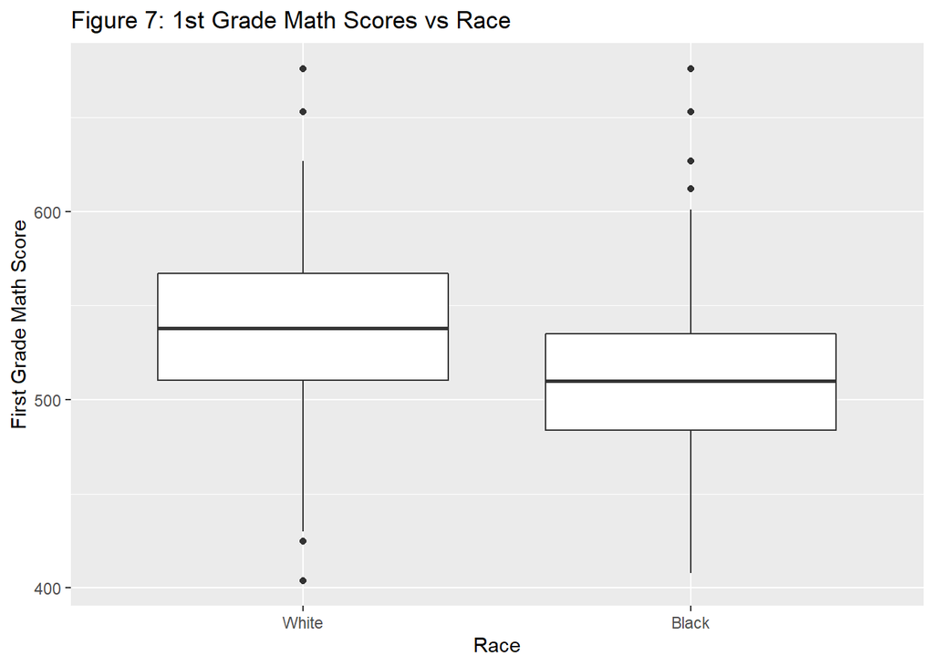

Looking beyond student characteristics, there is heterogeneity in the distribution of math scores across school systems, as shown in the boxplots below.

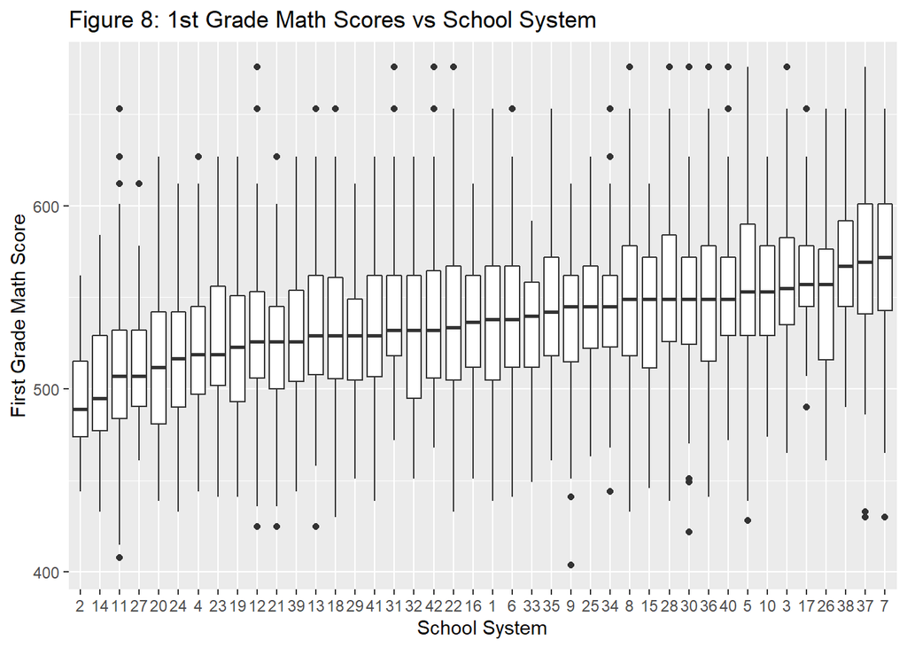

The setting in which a school is located appears to be associated with first grade math scores, as shown in the boxplots below. Students in “inner-city” schools tended to have lower scores than others, and students in “rural” schools have the highest median score. 47% of first grade observations are from rural schools.

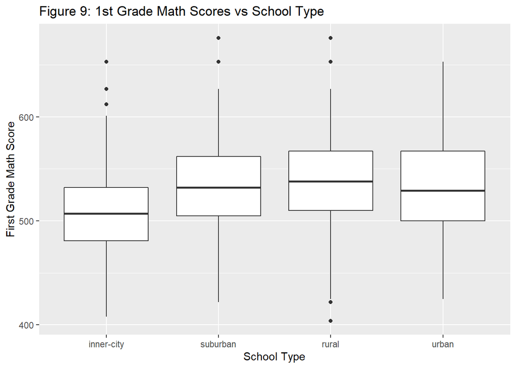

How are teachers’ features associated with math scores? Below are boxplots of the first grade math scores by first grade teacher’s degree. Specialist and PhD degrees were not included because of the small number of observations. Masters-educated teachers are associated with slightly higher scores. 65% of students had teachers with bachelors degrees and 34% of students had teachers who were masters-educated. As noted above, only 1 class of students had a teacher with a PhD, and 2 classes had teachers with specialist degrees.

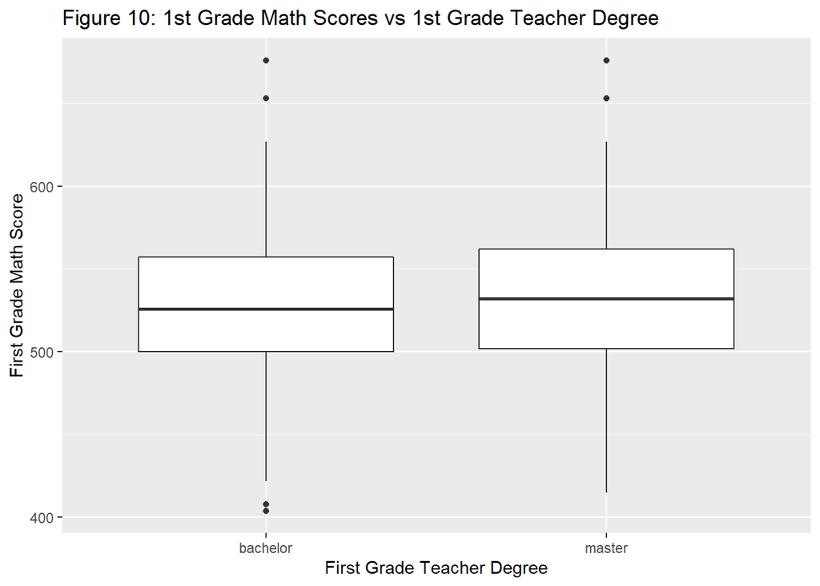

There are differences in the distribution of math scores by teacher career ladder level, and the relationship across levels 1, 2, and 3 is not monotonically increasing as one would expect. The majority of students had teachers who were level 1 - 66%. Only 1.6% of students had teachers who were level 2, and 4.3% of students had teachers who were level 3. Apprentice, probation, and not-ladder were the more common ladders, with 11%, 10%, and 7%, respectively. Note that these are counts of students, not teachers, such that a single teacher is counted for each student in their class.

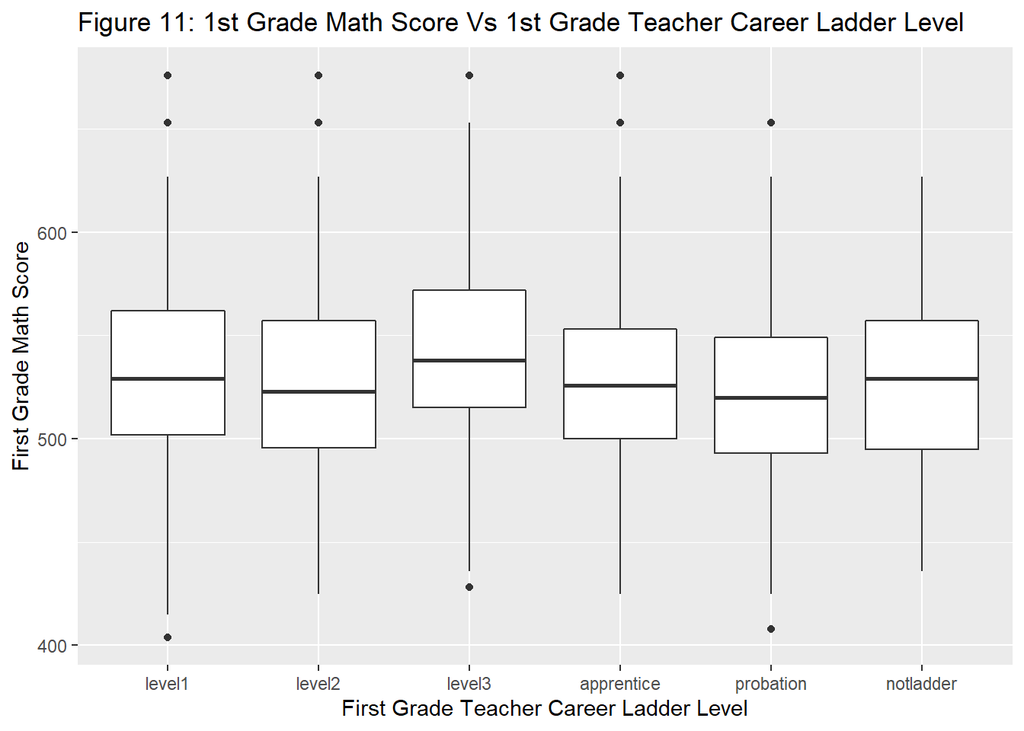

Meanwhile, a teacher’s years of experience does not appear to be associated with first grade math scores, as shown in the jittered scatterplot below. The Spearman correlation coefficient between the two variables is 0.004.

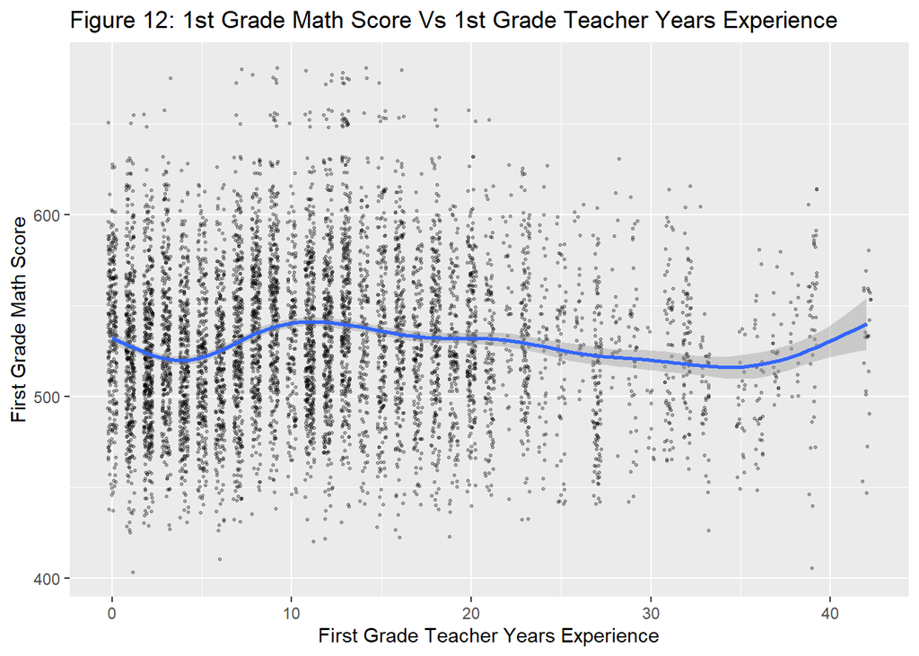

As shown above, black students tend to have lower scores than white students, yet, interestingly, black students with black teachers tend to have higher scores than black students with white teachers. And white students with white teachers tend to have higher scores than white students with black teachers. This may suggest that having a teacher of the same race is associated with improved math scores.

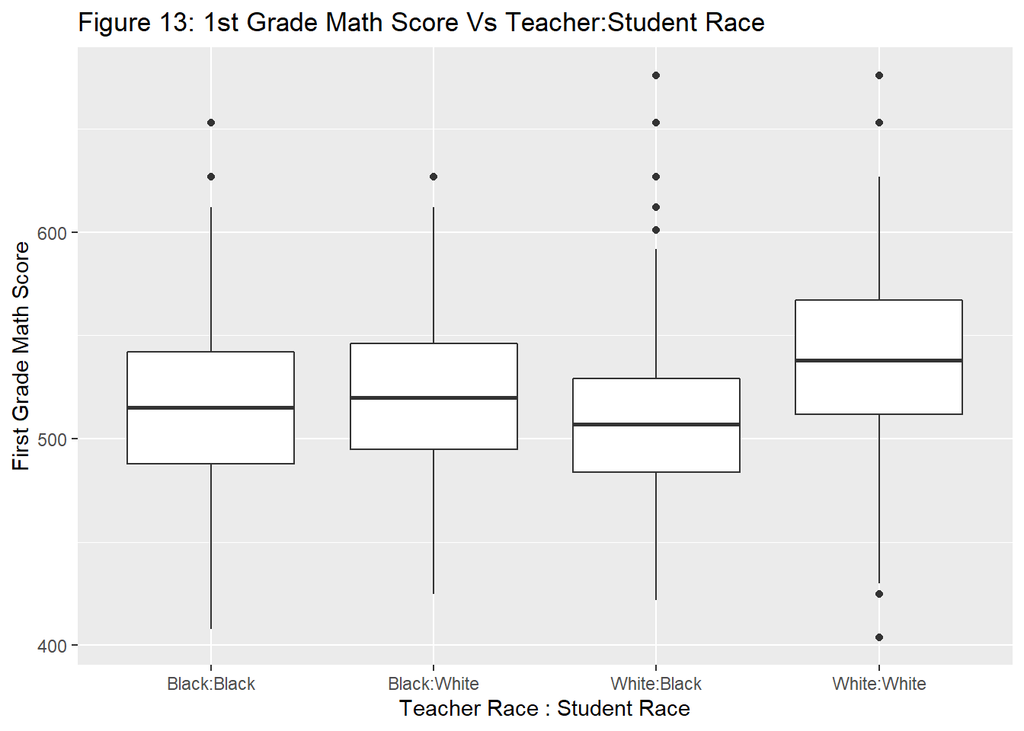

Thus, there are many covariates that are associated with first grade math scores. Note that all of the associations listed above are merely associations and do not indicate causality.

## Statistical Question of Interest

The primary focus of this project is to determine whether or not there is a significant influence of class size on math scores of the 1st graders that participated in this study. The approach used was to model the data with a regression model. ANOVA was used to determine whether there was a significant difference between scores of students in the different class types. The resulting difference was then analyzed further with Scheffe’s procedure.

## One-way ANOVA model

We are interested in examining the influence of class size on 1st grade math scores.

The following regression model was chosen:

$y$ = $\sf{b_{0}}$ + $\sf{b_{1}}$ * $\sf{x_{1}}$ + $\sf{b_{2}}$ * $\sf{x_{2}}$ + $\epsilon$

where:

$y$ = math scores for the 1st graders in the STAR study

$\sf{b_{0}}$ = the y -intercept (baseline score)

$\sf{b_{1}}$ = coefficient for the small class size term

$\sf{x_{1}}$ = small class size term, dummy variable where ($\sf{x_{1}}$ = 1 if student is in small class, 0 if not)

$\sf{b_{2}}$ = coefficient for regular class size with aide term

$\sf{x_{2}}$ = regular class size with aide term, dummy variable where ($\sf{x_{2}}$ = 1 if student is in reg w/aide class , 0 if not)

$\epsilon$ = error term

Note the third class size (regular only) is indicated by $\sf{x_{1}}$ and $\sf{x_{2}}$ both equal to zero.

Dummy variables were used because the class size data was categorical, with students being only in one of the categories.

**Table 2: ANOVA Table**

[output not shown]

The initial hypothesis is that the means of all of the class sizes are equal. The ANOVA table compares between group variation (factor) with within group variation (error). The F ratio calculates the ratio of the mean squared factor variation over the mean squared error variation, with larger F ratios signifying that the means of the class sizes are not equal. The P-value was 2e-16 << 0.05 which is very significant and therefore we can conclude that the hypothesis that the means of the math scores of students are equal for all class sizes is rejected.

## Model Fit

The fitted model is :

Fitted line: $y$ = 525.2744 + 13.4033 * $\sf{x_{1}}$ + 4.3507 * $\sf{x_{2}}$ + $\epsilon$

A linear fit of the math scores regressed on class size gave coefficients of 13.4033 for the small class size term, 4.3507 for the regular class with aide term, and 525.2744 for the baseline score. All of these values were significant with P-values close to zero. (See R output in Appendix)

## Model Diagnostics and Sensitivity Analysis

## Model Assumptions of the ANOVA

The underlining assumptions for conducting an ANOVA require that (1) each observed value is independent of another (i.e. one student’s math score does not impact the score of another), (2) the observed values together take on a normal (symmetric and bell-shaped) distribution within each group being compared, and (3) that the variance of the observed values within each group are similar.

Since the study design implies that each student’s math score was included only once, it is assumed they are independent from one another.

As for the normality assumption, there do not appear to be any alarming outliers seen in the individual group’s distribution of math scores suggesting skewness in one direction or the other (Figure 14). The histogram of the individual group’s math scores appear to be relatively similar as well.

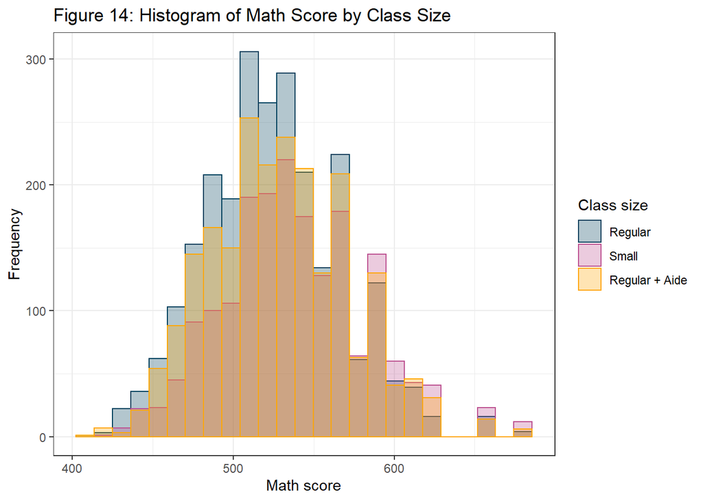

Further evaluation of the normal assumption shows that the difference between each student’s score and the mean score (i.e. residuals), also appears to be normally distributed (Figure 15). A quantile-quantile plot suggests the same (Figure 16). Thus, there are no alarming violations of the normality assumption.

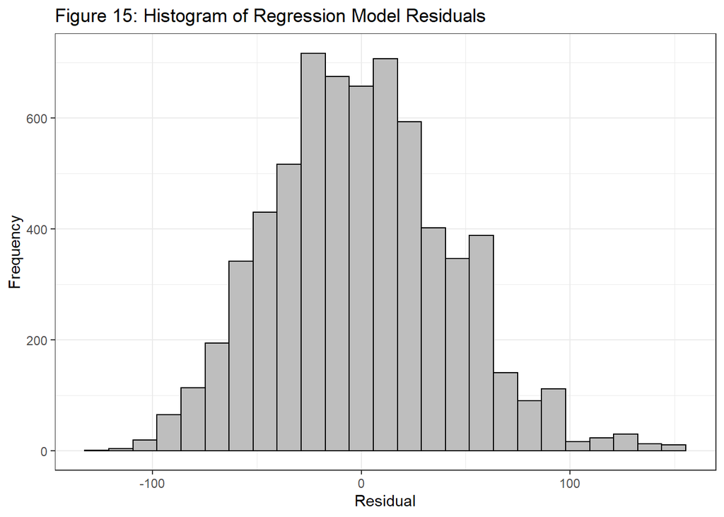

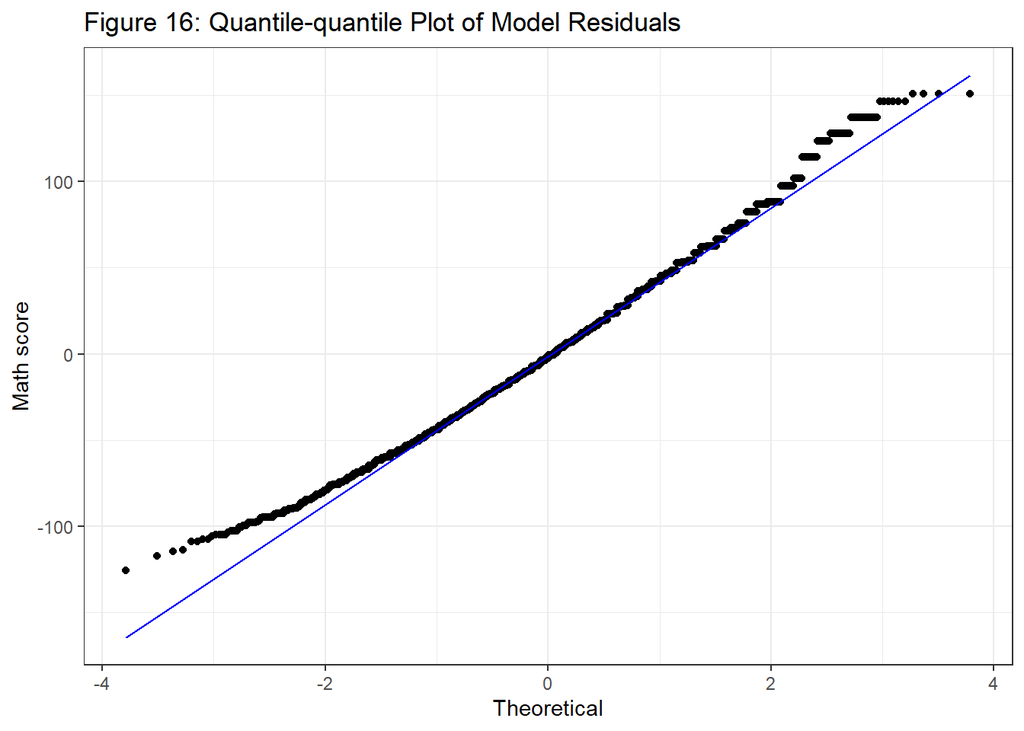

A histogram of the residual values within each arm suggests that the three class size groups share a common variance (Figure 17). The distributions are each relatively similarly dispersed, satisfying the constant variance assumption of the ANOVA.

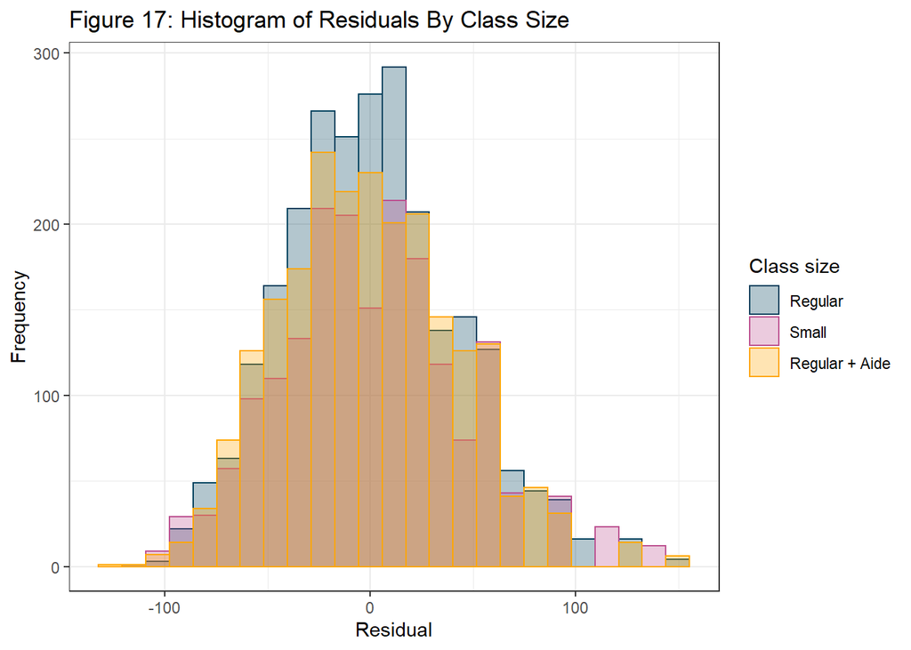

The requirements for the regression model were therefore satisfied as well (see above) for normality, independence and heteroscedasticity.

## Scheffe’s Test

We now investigate the hypothesis that all class sizes have the same effect on the math scaled scores for grade 1. We define our hypothesis as

$H_0$: All class sizes have equal math scaled scores mean for grade 1 VS $H_a$: Not all class sizes have equal math scaled scores mean for grade 1.

From the result of our analysis of variance of the math scaled scores for the grade 1 pupils, we decide our data does not provide evidence towards the null hypothesis. Thus, we reject the null hypothesis. This implies there are significant differences in the average math scaled scores for the class types.  
However, which class type can be said to be different and which class types are not distinguishable? To understand this, we perform a pairwise comparison of the means of the class types. We obtain Scheffe family-wise significance level of 0.05.

We observe that the class type means are different. We present the results from the Scheffe’s method in the table below. We chose the Scheffe’s method since it is more appropriate for unbalanced data, of which our data is one.

**Table 3: Scheffe’s Method Results**

[output not shown]

From the table, we can see that on average, the students in small class types performed better than those in the regular class type with or without aide.

## Causal Inference

In order to go beyond the vast evidence that suggests students in the small class type do have a better math scaled score than other class types, we investigate the randomization process at the heart of project STAR.

1. Selection of Schools: Schools were properly spread out across Tennessee. Schools from inner cities, urban, suburban and rural areas were all participants in the project. All schools from the Tennessee school systems were invited to participate. There were provisions for additional costs for project teachers and teacher aides, and that local systems would furnish any additional classroom space needed.
2. Hawthorne Effect: Some non-STAR elemenentary schools were choosen as comparison schools to ascertain if there were any alterations of behavior by the subjects of Project STAR due to their awareness of being observed. 22 comparison schools with 51 regular class size were drawn from 17 STAR school systems. This totals into approximately 1,100 students. The students in the comparison schools were administered the same tests as the project schools.
3. Selection of Teachers and Students: Teachers in participating school were required to be certified for their grade levels. Participating schools randomly assigned teachers and students to different class types.
4. Voluntary Participation: Students, teachers and schools participating in STAR are not to receive fewer services than if they weren’t participating.

With the three randomizations, one could potentially argue that most if not all major confounding conditions are taken care of. Thus, one could suggest the observed association with respect to the math scaled score is majorly an effect of class sizes.

## Discussion

This analysis of the 1980’s STAR study data found that during the grade 1 cross section of students, those randomly assigned to the small class size outperformed those students in both the regular and regular + aide groups in scaled math score. Students in small classroom sizes showed an average increase of up to 17 points in their math scaled score (mean difference small minus regular class size: 13 [95% CI: 10, 17]).

Though, this mean difference is arguably modest. Provided these data also showed an overall mean math score of 531 (standard deviation: 43) and range of 404 to 676, a best-case mean improvement of 17 points seems to question the effectiveness of the intervention. It must be examined whether these results merit a seemingly costly 40% reduction in class size (from 22-25 to 13-17).

For every 1,000 students, reducing class sizes would require around 19 additional teachers ([1000/17] - [1000/25] = 19). In modern day, typical elementary schools vary in the number of students per school, with an average of 473 students per elementary school (SOURCE BELOW). Hypothetically assuming the regular class size remains unchanged, implementing this policy change would require an additional nine teachers per school ([473/1000] * 19 = 9). With median elementary teacher salaries hovering around $45,000, this equates to an additional $405,000 per year in average salary expense alone for each elementary school.

There is an inherent philosophical challenge in putting a price on education for young, evolving minds. However, publicly funded primary schools must evaluate cost when evaluating policy change. Although this study randomized students to class size types, simply comparing the over mean performance of each class size does not take into account individual school’s community demographics, socioeconomic characteristics, nor the initial challenges some students face, regardless of class size. Indeed the one-way analysis of variance method employed here comparing overall group means allows for generalizability of similar large groups. However this univariate method does not incorporate other sensitive student characteristics nor predictors of academic success. Previous academic scores, ethnicity of students and teachers, and indicators of socioeconomic class like free-lunch qualification could be meaningful attributes to explore in further analysis.

A more insightful multivariable analysis of this study’s critical data may include these important features as predictors of scaled math scores, or at minimum, as confounders to student success. Potential subgroup analysis of poorly performing and excelling students in this randomized trial may frame the effect of class size on math scores in a much more meaningful way.

## Appendix: R Output

ANOVA model

```
##               Df   Sum Sq Mean Sq F value              Pr(>F)
## star1          2   195075   97538   53.33 <0.0000000000000002 ***
## Residuals   6597 12065523    1829
## ---
## Signif. codes:  0 '***' 0.001 '**' 0.01 '*' 0.05 '.' 0.1 ' ' 1
## 4998 observations deleted due to missingness
```

Linear Regression Model

```
##
## Call:
## lm(formula = star$math1 ~ star$star1)
##
## Residuals:
##      Min       1Q   Median       3Q      Max
## -125.625  -30.274   -2.274   27.726  150.726
##
## Coefficients:
##                        Estimate Std. Error t value             Pr(>|t|)
## (Intercept)            525.2744     0.8541 614.984 < 0.0000000000000002 ***
## star$star1small         13.4033     1.3071  10.254 < 0.0000000000000002 ***
## star$star1regular+aide   4.3507     1.2456   3.493             0.000481 ***
## ---
## Signif. codes:  0 '***' 0.001 '**' 0.01 '*' 0.05 '.' 0.1 ' ' 1
##
## Residual standard error: 42.77 on 6597 degrees of freedom
##   (4998 observations deleted due to missingness)
## Multiple R-squared:  0.01591,    Adjusted R-squared:  0.01561
## F-statistic: 53.33 on 2 and 6597 DF,  p-value: < 0.00000000000000022
```

## Sources

[1] “The State of Tennessee’s Student/Teacher Achievement Ratio Project: Technical Report, 1985-1990” https://www.classsizematters.org/wp-content/uploads/2016/09/STAR-Technical-Report-Part-I.pdf

[2] US National Center for Education Statistics “Public elementary schools, by grade span, average school size, and state or jurisdiction: 2005-06” https://nces.ed.gov/programs/digest/d07/tables/dt07_095.asp